# 550_Correlation Notes

```r
# Display output within the notebook
# knitr::opts_chunk$set(echo = TRUE, results = 'show')
```

# Scatterplots

“The greatest value of a picture is when it forces us to notice what we never expected to see,” John Tukey

- One quantitative variable: dotplot, stemplot, boxplot, histogram
- One categorical variable: pie chart, bargraph
- One quantitative across (categorical) groups: parallel boxplots, side-by-side stemplot
- Two categorical variables: mosaic plot, segmented bar graph, side-by-side bar graph
- Two quantitative variables?

Scatterplots help us visualize the relationship between two quantitative variables measured on the same individuals.

Companies work hard to have their website listed at the top of an internet search.

Is there a relationship between a website’s position in the results of an internet search (1 = top, 2 = second position, etc.) and the percentage of people who click on the link for the website?

Here are click-through rates for the top 10 positions in searches on a mobile device (TPS7, p. 176).

```r
position <- 1:10
rate <- c(23.53, 14.94, 11.19, 7.47, 5.29, 3.8, 2.79, 2.11, 1.57, 1.18)

# Create scatterplot
plot(position,                    # variable on x-axis
     rate,                        # variable on y-axis
     pch = 16,                    # filled-in circles
     cex = 2,                     # larger circle size
     las = 3,                     # rotate numbers on y-axis
     xlab = "Position",           # x-axis label
     ylab = "Click-through Rate") # y-axis label

# If the variables are columns within a dataframe df, use plot(df$col1, df$col2, ...)
```

### Describe the scatterplot.

- **Direction** (positive, negative, or no)
- **Form** (linear or non-linear)
- **Strength** (weak, moderate, strong)
- **Unusual features** (outliers, clusters, etc.)

Trend, not absolute relationship (i.e., not “deterministic”)

Quantitative vs. Categorical

Correlation, Association, Relationship

# —

# Correlation

Direction, Form, Strength, Unusual Features

Visual estimate vs. numerical summary

```r
plot(position,
     rate,
     pch = 16,
     cex = 2,
     las = 1,
     xlab = "Position",
     ylab = "Click-through Rate")

cor(position, rate)
```

### Pearson’s correlation coefficient r

A statistic that measures the **strength** and **direction** of a linear association between two quantitative variables

- between -1 and 1, inclusive, aka, $|r| \le 1$
- r > 0 : positive association

```r
hours <- c(0, 0, 1, 2, 2, 3, 5, 7)
score <- c(0, 10, 50, 60, 65, 70, 80, 100)

# Visualize with a scatterplot
plot(hours, score, pch = 16, cex = 2, main = "Positive association")

# Calculate the correlation
cor(hours, score)
```

- r < 0 : negative association

```r
hours <- c(0, 0, 1, 2, 2, 3, 5, 7)
score <- c(100, 80, 70, 65, 60, 50, 10, 0)

plot(hours, score, pch = 16, cex = 2, main = "Negative association")

cor(hours, score)
```

- r = 0 tells us there is no **linear** association between x & y

```r
# For reproducibility
set.seed(1)

# Fake data with r = 0
fake_x <- rnorm(100, mean = 80, sd = 5)
fake_y <- rnorm(100, mean = 80, sd = 5)

# Change viewing window to see two graphs at once: 1 row, 2 columns
par(mfrow = c(1, 2))

plot(fake_x,
     fake_y,
     las = 1,
     pch = 16,
     main = paste("r =", round(cor(fake_x, fake_y), 2))) # Show the correlation on main title

# Make another r = 0 relationship
fake_x2 <- rnorm(100, mean = 0, sd = 5)
fake_y2 <- fake_x2^2 + rnorm(100, mean = 0, sd = 3)

plot(fake_x2,
     fake_y2,
     las = 1,
     pch = 16,
     main = paste("r =", round(cor(fake_x2, fake_y2), 2)))
```

- Extreme values of -1 and 1 occurs only in the case of **perfect linear** relationship (i.e., all points fall exactly on the line)

```r
# Change viewing window to see two graphs at once: 1 row, 2 columns
par(mfrow = c(1, 2))

# Positive association
plot(fake_x,
     fake_x, # plotting identical variable to demonstrate correlation r = 1
     las = 1,
     pch = 16,
     main = paste("r =", round(cor(fake_x, fake_x), 2)),
     xlab = "",
     ylab = ""
     )

# Negative association
plot(fake_x,
     -fake_x,
     las = 1,
     pch = 16,
     main = paste("r =", round(cor(fake_x, -fake_x), 2)),
     xlab = "",
     ylab = ""
     )
```

- |r| close to 1 is “strong”
- |r| close to 0 is “weak”

| **Strong** | **Moderate** | **Weak** | **Moderate** | **Strong** |
| --- | --- | --- | --- | --- |
| -0.8 to -1 | -0.8 to -0.5 | -0.5 to 0.5 | 0.5 to 0.8 | 0.8 to 1 |

- A “strong” correlation is dependent on your field (engineering different than social sciences)
- Correlation is not resistant to extreme values (outliers)

```r
# Scatterplot with outlier
hours <- c(0, 0, 1, 2, 2, 3, 5, 7)
score <- c(100, 80, 70, 65, 60, 50, 10, 100)

plot(hours, score, pch = 16, cex = 2, main = "With outlier", sub = paste("r = ", round(cor(hours, score), 3)))


# Scatterplot *without* outlier
hoursNoOutlier <- c(0, 0, 1, 2, 2, 3, 5)
scoreNoOutlier <- c(100, 80, 70, 65, 60, 50, 10)

plot(hoursNoOutlier, scoreNoOutlier, pch = 16, cex = 2, main = "Without outlier", sub = paste("r = ", round(cor(hoursNoOutlier, scoreNoOutlier), 3)))
```

- r = 0 means no “linear” association, but there may still be a pattern

```r
hours <- 1:8
score <- c(100, 80, 70, 65, 65, 71, 80, 100)

plot(hours, score, pch = 16, cex = 2, main = "No 'linear' association, but...")

cor(hours, score)
```

### Visuals on different strengths and directions

- [Matching Correlations](https://istics.net/Correlations/)
- [Guess the correlation](https://www.geogebra.org/m/KE6JfuF9)
- Rossman/Chance Applet: [Guess the correlation](https://www.rossmanchance.com/applets/2021/guesscorrelation/GuessCorrelation.html)

### For more on correlation, see the textbook:

- [The Correlation Coefficient](https://learningstatisticswithr.com/book/descriptives.html#the-correlation-coefficient)
- [Interpreting Correlations](https://learningstatisticswithr.com/book/descriptives.html#interpretingcorrelations)

# —

# Exploring with Scatterplots

The donors dataset comes from “Practical Machine Learning with R” by Nwanganga and Chapple (p. 166-68).

The dataset comes from a national veterans’ organization that frequently solicits donations through direct mail campaigns to its database of current and prospective donors. The organization sent out a test mailing to a group of potential donors and gathered information on the response to that test mailing.

#### Load the data

Download the `donors.csv` and this Rmd notebook from Brightspace.

Remember to save the CSV in the same folder as this Rmd notebook; otherwise, you will need to set your working directory. See previous module for assistance.

```r
# How do we load a CSV into R?
# Store the dataset into an object named "donors"
donors <- read.csv('donors - Copy.csv')
```

#### Initial Exploration

```r
# How do we do a quick analysis of the data?

summary(donors)

# Note some weird features!
# See ages, numberChildren, lots of NAs
# We need a codebook!
```

#### Are number of gifts correlated with gift amount?

```r
# This doesn't work:

plot(donors$averageGiftAmount, donors$numberGifts)

# How do we fix it?
```

```r
plot(donors$averageGiftAmount,
     donors$numberGifts,
     cex = 0.5, # make points smaller
     las = 1, # rotate numbers on y-axis for more readability
     pch = 16, # make solid dots
     xlab = "Average Gift Amount",
     ylab = "Number of Gifts")

# Calculate correlation
cor(donors$averageGiftAmount, donors$numberGifts,)

#direction = negative, strength: weak, form: non-=linerar/ curved , unusual: grouped in lower left.  outliers
```

#### Are the number of gifts correlated with the number of months since a donor’s last donation?

```r
# Without jitter
plot(donors$monthsSinceLastDonation,
     donors$numberGifts,
     cex = 0.5,
     las = 1,
     pch = 16,
     xlab = "Months since Last Donation",
     ylab = "Number of Gifts")

# With jitter
plot(jitter(donors$monthsSinceLastDonation, 0.5), # add jitter so points don't overlap as much
     donors$numberGifts,
     cex = 0.5,
     las = 1,
     pch = 16,
     xlab = "Months since Last Donation",
     ylab = "Number of Gifts")

# Calculate correlation
```

#### Your turn: create a scatterplot and calculate correlation of two variables of your choice.

1. Use donors dataset…or…
2. Find (or collect) data with at least two quantitative variables. Share it!

```r
# Scatterplot

#11th comlum
names(donors)[11]
names(donors)

# Correlation
```

# —

# Correlation Matrices and Scatterplot Matrices

## Visualizing Correlations

We often want to calculate the correlation between several variables simultaneously.

First, I will shorten a variable name so the output is cleaner.

```r
# 11th column
names(donors)

names(donors)[11]
```

```r
names(donors)[11] <- "yrsFirstDon"

names(donors)

# See update in environment too!
```

```r
# cor(df[rows, columns])

# Identify the quantitative variables I'm interested in:
donorsNumeric <- donors[, c("numberChildren",
               "incomeRating",
               "wealthRating",
               "smallestGiftAmount",
               "yrsFirstDon"
               )]
donorsNumeric
```

```r
# Create correlation matrix
round(cor(donorsNumeric), 2)

# R = 1
plot(donors$numberChildren, donors$numberChildren, pch = 16, cex = 1.5)
```

```r
# Check the documentation

?cor()
```

`use` = an optional character string giving a method for computing covariances in the presence of missing values.

- “everything”
- “all.obs”
- “complete.obs”
- “na.or.complete”
- “pairwise.complete.obs”

## Dealing with NAs

`cor(df$var1, df$var2, use = "complete.obs")`

```r
round(cor(donorsNumeric,
          use = "complete.obs"), 2)
```

## A scatterplot matrix

With large datasets, we often want to visualize the relationships between many variables at once.

`pairs()`

You’ll learn more ways to visualize relationships in DTSC-650 *Data Analytics with R*.

```r
pairs(donors[, c("wealthRating",
               "smallestGiftAmount",
               "yrsFirstDon"
               )])
```

```r
### All in one line to note the syntax

# pairs(donors[, c("wealthRating", "smallestGiftAmount", "yrsFirstDon")])
```

#### A Cleaner `pairs()`

This is much nicer syntax! And, no need to make a new dataframe, like *donorsNumeric*

```r
pairs(~ wealthRating + smallestGiftAmount + yrsFirstDon,
      data = donors,
      na.action = na.omit)
```

# —

# How is correlation calculated manually?

## 1. Using Covariance

How is the sample covariance calculated?

$$Cov(x, y) = \frac{\Sigma(x_i-\bar{x})(y_i-\bar{y})}{n-1}$$

If $Cov(X, Y) > 0$, we say X and Y are *positively* correlated: on average, X and Y are either both greater or less than their respective means.

If $Cov(X, Y) < 0$, we say X and Y are *negatively* correlated: on average, one of X or Y is greater than and one less than their mean.

```r
# Calculate covariance manually

# Data
position <- 1:10
rate <- c(23.53, 14.94, 11.19, 7.47, 5.29, 3.8, 2.79, 2.11, 1.57, 1.18)

# Calculate means
mean(position)
```

```
[1] 5.5
```

```r
mean(rate)
```

```
[1] 7.387
```

```r
# Calculate deviations
deviation_positions <- position - mean(position)
deviation_rates <- rate - mean(rate)

# Print
deviation_positions
```

```
 [1] -4.5 -3.5 -2.5 -1.5 -0.5  0.5  1.5  2.5  3.5  4.5
```

```r
deviation_rates
```

```
 [1] 16.143  7.553  3.803  0.083 -2.097 -3.587 -4.597 -5.277 -5.817 -6.207
```

```r
# Find products
# Note we're multiplying the coordinates in each (x, y) pair
products <- (deviation_positions) * (deviation_rates)
products
```

```
 [1] -72.6435 -26.4355  -9.5075  -0.1245   1.0485  -1.7935  -6.8955 -13.1925 -20.3595 -27.9315
```

```r
# Find sum of products
sum_products <- sum(products)
sum_products
```

```
[1] -177.835
```

```r
# Find "average"
my_covariance <- sum_products / (length(products)-1)
my_covariance
```

```
[1] -19.75944
```

$$cov(x, y) = \frac{\Sigma(x_i-\bar{x})(y_i-\bar{y})}{n-1}$$

```r
# Calculate covariance with short-cut
cov(position, rate)
```

What would the units be?

Suppose x = years and y = dollars. What would be the units of covariance be?

## Why we don’t use covariance…

Covariance…

- no bound to covariance
- has (strange) units
- units vary making it an unhelpful statistic to compare association for different variables

We need to standardize the covariance to make it more useful.

$$z = \frac{x-\mu}{\sigma}$$

```r
# Calculate standard deviations of x and y
sd_position <- sd(position)
sd_rate <- sd(rate)

# Calculate correlation using covariance

my_covariance / (sd_position*sd_rate)
```

```
[1] -0.9024191
```

```r
# Verify the correlation with R function

cor(rate, position)
```

```
[1] -0.9024191
```

The *Pearson’s correlation coefficient* r is

$$r = \frac{Cov[X, Y]}{\sigma_X*\sigma_Y}$$

## 2. Using Z-scores

$$r = \frac{\Sigma (z_x*z_y)}{n-1} \\$$

$$r =
\frac{1}{n-1}\Sigma(\frac{x_i-\bar{x}}{s_x})(\frac{y_i-\bar{y}}{s_y})$$

```r
# Challenge: Work through the manual calculations of z-scores to calculate the correlation.
# Tip: Do piece-by-piece, rather than everything all at once.
```

This formula is helpful in understanding properties of correlation, which we’ll see in a later video.

## 3. R short-cut

We definitely prefer this way!

```r
cor(rate, position)
```

### Another formula for correlation

A relic of the pre-computer age.

$$r =
\frac{\Sigma(x_i-\bar{x})(y_i-\bar{y})}{\sqrt{\Sigma(x_i-\bar{x})^2}*\sqrt{\Sigma(y_i-\bar{y})^2}}$$

### Final Note on Population vs. Sample Covariance

The *sample* covariance in this formula:

$$Cov(x, y) = \frac{\Sigma(x_i-\bar{x})(y_i-\bar{y})}{n-1}$$

The *population* covariance is this formula:

$$Cov(x, y) = \frac{\Sigma(x_i-\mu_x)(y_i-\mu_y)}{N}$$

For the sample covariance to be an unbiased estimator of the population covariance, we divide by `n-1`.

# —

# Properties of Correlation

$$r = \frac{\Sigma (z_x*z_y)}{n-1}$$

```r
# Data for illustration
x <- 1:10
y <- c(2, 5, 13, 7, 8, 10, 12, 14, 17, 25)

my_cor <- round(cor(x, y), 3)

plot(x, y,
     main = paste("r =", my_cor), # Include the correlation right on the graph with paste()!
     pch = 16,
     las = 1)
```

## 1. R requires quantitative variables, not categorical

```r
z <- c(rep("yes", 4), rep("no", 6))
z

#cor(x, z)
```

Note: We could encode the categories as numbers!

- Binary
- Ordinal
- Nominal

## 2. R makes no distinction between explanatory and response variables

```r
# Data for illustration
x <- 1:10
y <- c(2, 5, 13, 7, 8, 10, 12, 14, 17, 25)

plot(x, y, main = paste("r =", round(cor(x, y), 3)), pch = 16, las = 1)

# Switch x and y
y <- 1:10
x <- c(2, 5, 13, 7, 8, 10, 12, 14, 17, 25)

plot(x, y, main = paste("r =", round(cor(x, y), 3)), pch = 16, las = 1)
```

## 3. R does not change if you change units; it is not affected by adding or multiplying each data value by a constant

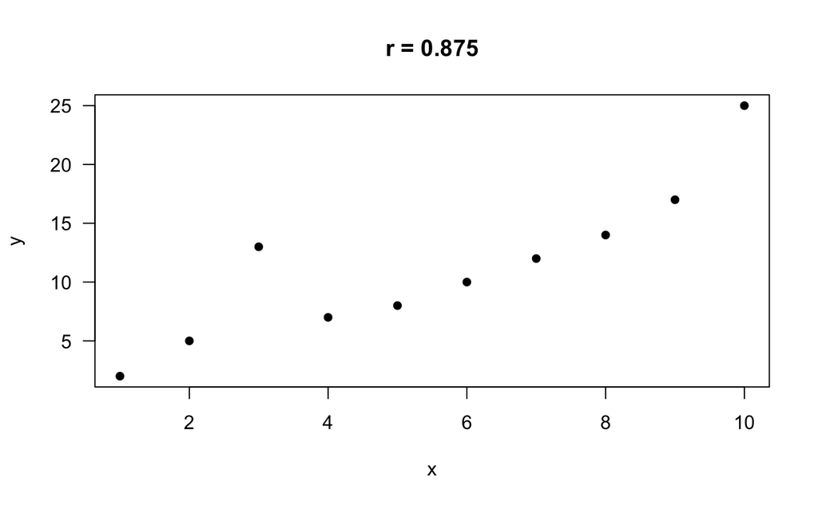

```r
# Data for illustration
x <- 1:10
y <- c(2, 5, 13, 7, 8, 10, 12, 14, 17, 25)

plot(x, y, main = paste("r =", round(cor(x, y), 3)), pch = 16, las = 1)
```

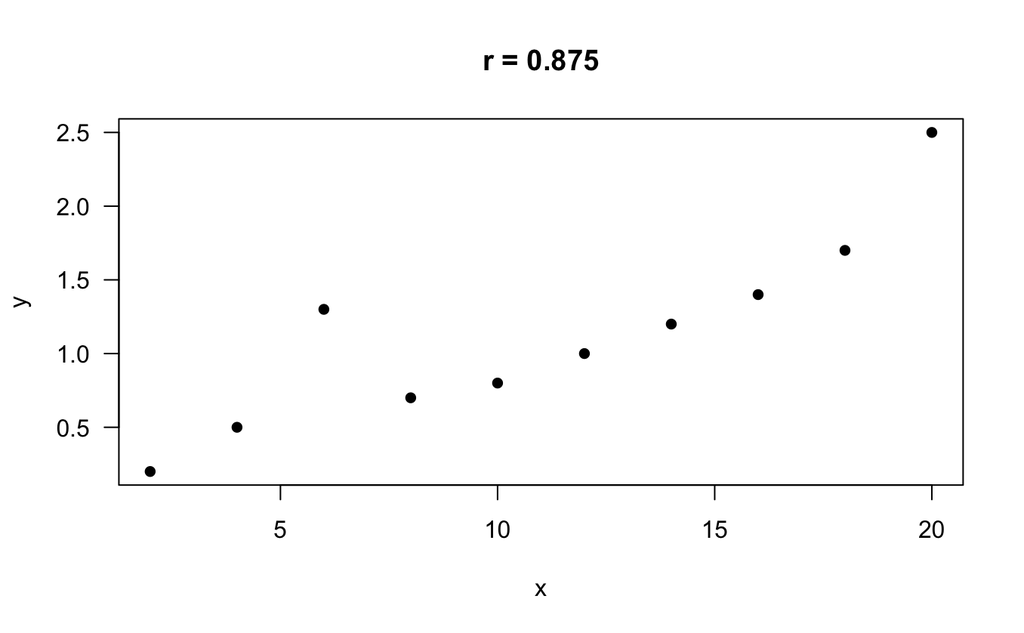

```r
# Change the units
x <- 2*(1:10)
y <- c(2, 5, 13, 7, 8, 10, 12, 14, 17, 25)/10

plot(x, y, main = paste("r =", round(cor(x, y), 3)), pch = 16, las = 1)
```

Covariance changes based on units; correlation does not.

- “Standardized Covariance”

## 4. R has no unit of measurement (so it’s not a percent!)

r = 0.875

## 5. The sign of r always matches the direction of the linear relationship.

```r
my_x <- donors$numberGifts
my_y <- donors$totalGivingAmount

plot(my_x,
     my_y,
     xlab = "Number of Gifts",
     ylab = "Total Giving ($)",
     pch = 16,
     main = paste("r =", round(cor(my_x, my_y), 4))
)
```

## 6. R is not resistant to extreme values

#### [Investigate](https://digitalfirst.bfwpub.com/stats_applet/stats_applet_5_correg.html)

Fill-in-the-blank with “strengthen” or “weaken” or “keep about the same”:

#### Adding observations

- Adding a point outside the trend will _ the correlation.
- Adding a point inside the trend will _ the correlation.

#### Removing observations

- Removing a point that is outside the trend will _ the correlation.
- Removing a point that is inside the trend will _ the correlation.

# —

# The Main Caution about Correlation

Just because two variables are strongly associated does not mean one *causes* the other.

## 1. Correlation does not imply causation

Chocolate Consumption, Cognitive Function, and Nobel Laureates

Response

- Is x causing y? Maybe y is causing x? Maybe z is causing x and y?
  - [Causal Diagrams](https://www.ibpsychmatters.com/why-correlation-is-not-causation)

More examples

- [Coffee = Long Life?](https://www.cnbc.com/2017/07/11/coffee-drinking-could-lead-to-longer-life-studies-say.html)
- See spurious correlations [here] (https://tylervigen.com/spurious-correlations)
- [Luke 5:29-32](https://www.biblegateway.com/passage/?search=Luke%205%3A29-32&version=NLT), [Luke 7:36-50](https://www.biblegateway.com/passage/?search=Luke%207%3A36-50&version=TLB) Association does not imply causation

### More on causation

- Randomized experiments ([A/B testing](https://hbr.org/2017/06/a-refresher-on-ab-testing))
- Observational studies and [Hill’s Criteria](https://en.wikipedia.org/wiki/Bradford_Hill_criteria) (cf. [critical discussion](https://www.rtihs.org/sites/default/files/26902%20Rothman%201998%20The%20encyclopedia%20of%20biostatistics.pdf))
- Judea Pearl and Dana Mackenzie, *The Book of Why: The New Science of Cause and Effect* (2018)
  - The book explores the subject of causality and causal inference from statistical and philosophical points of view for a general audience
- Correlation does not imply causation…but it might!

# —

# More Cautions about Correlation

## 2. A correlation close to -1 or 1 doesn’t imply the association is linear

```r
plot(position, rate,pch = 16, cex = 2, las = 1, xlab = "Position", ylab = "Click-through Rate", main = paste("r = ", round(cor(position, rate), 3)))
```

See [applet](https://digitalfirst.bfwpub.com/stats_applet/stats_applet_5_correg.html)

## 3. A correlation close to 0 does not imply there is no association at all

```r
# Make some non-linear (curved) data
x <- c(-5:5)
y <- x^2

plot(x,
     y,
     xlab = "",
     ylab = "",
     pch = 16,
     main = paste("r =", round(cor(x, y), 4))
)
```

## 4. Do not use Pearson’s correlation coefficient to describe non-linear relationships

Other options: Spearman’s Rank, Kendall’s Tau, Xsi

### Example

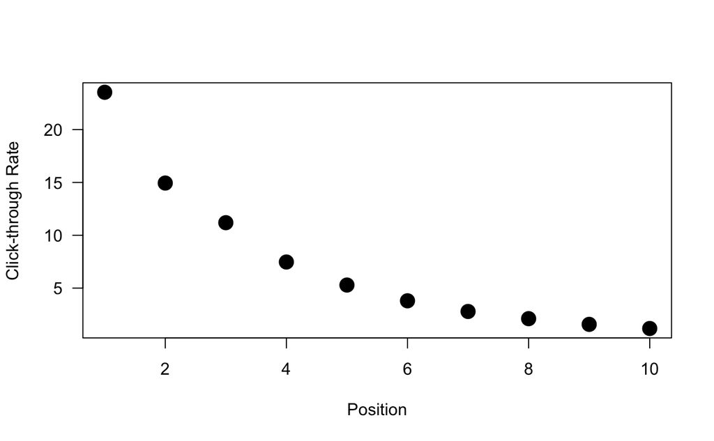

```r
# Non-linear scatterplot 1
plot(position,
     rate,
     pch = 16,
     cex = 2,
     las = 1,
     xlab = "Position",
     ylab = "Click-through Rate")
```

```r
cor(position, rate)
```

```
[1] -0.9024191
```

```r
# Defaults
#cor(position, rate, use = "everything", method = "pearson")

# A different method
cor(position, rate, method = "spearman")
```

```
[1] -1
```

### One more example

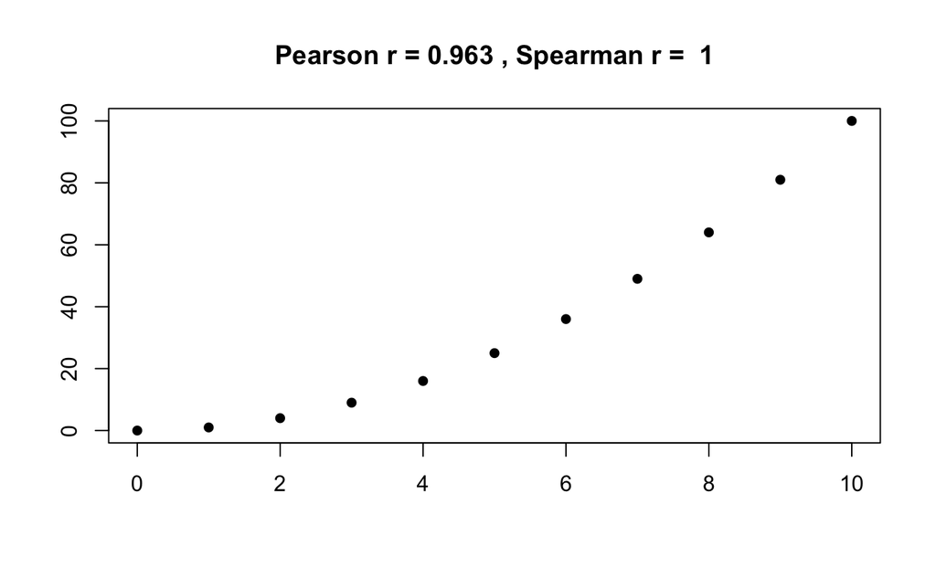

```r
# Make some non-linear (curved) data
x <- c(0:10)
y <- x^2

plot(x,
     y,
     xlab = "",
     ylab = "",
     pch = 16,
     main = paste("Pearson r =",
                  round(cor(x, y), 3),
                  ", Spearman r = ",
                  round(cor(x, y, method = "spearman"), 3))
)
```

```r
# Compare with Spearman's rank correlation
cor(x, y, method = "spearman")
```

```
[1] 1
```

## 5. Always plot your data!

Frank Anscombe (1918–2001) was an English statistician who generated the values in “Anscombe’s Quartet”

```r
anscombe
```

| x1 | x2 | x3 | x4 | y1 | y2 | y3 | y4 |
| --- | --- | --- | --- | --- | --- | --- | --- |
| 10 | 10 | 10 | 8 | 8.04 | 9.14 | 7.46 | 6.58 |
| 8 | 8 | 8 | 8 | 6.95 | 8.14 | 6.77 | 5.76 |
| 13 | 13 | 13 | 8 | 7.58 | 8.74 | 12.74 | 7.71 |
| 9 | 9 | 9 | 8 | 8.81 | 8.77 | 7.11 | 8.84 |
| 11 | 11 | 11 | 8 | 8.33 | 9.26 | 7.81 | 8.47 |
| 14 | 14 | 14 | 8 | 9.96 | 8.10 | 8.84 | 7.04 |
| 6 | 6 | 6 | 8 | 7.24 | 6.13 | 6.08 | 5.25 |
| 4 | 4 | 4 | 19 | 4.26 | 3.10 | 5.39 | 12.50 |
| 12 | 12 | 12 | 8 | 10.84 | 9.13 | 8.15 | 5.56 |
| 7 | 7 | 7 | 8 | 4.82 | 7.26 | 6.42 | 7.91 |

[output cut: 1 more lines]

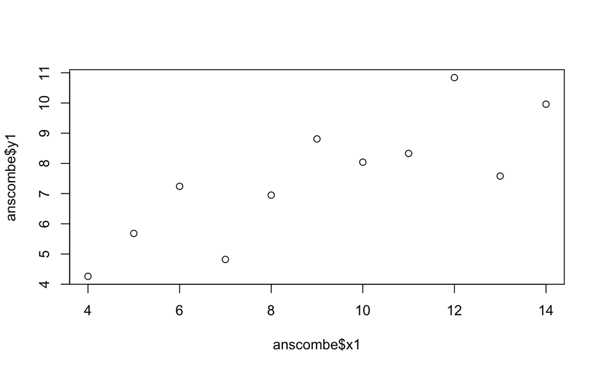

```r
# Plot 1
plot(anscombe$x1, anscombe$y1)
```

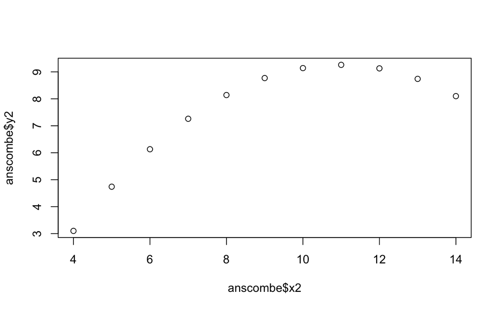

```r
# Challenge 1:
## Create the other three scatterplots for the following variables:

### Plot 2 of x2 vs. y2
plot(anscombe$x2, anscombe$y2)
```

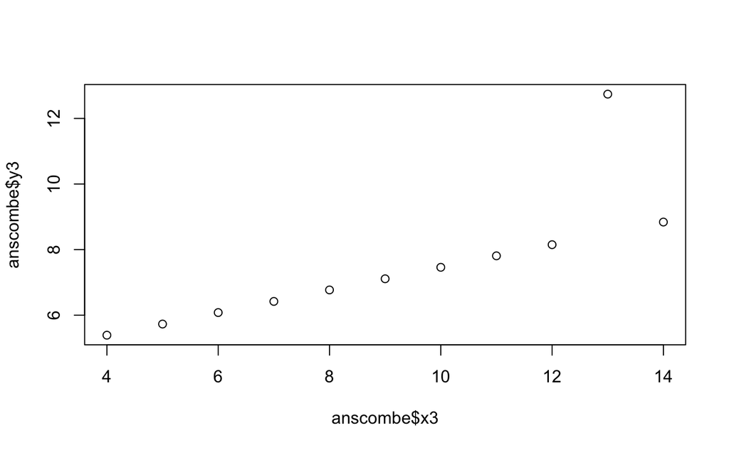

```r
### Plot 3 of x3 vs. y3

plot(anscombe$x3, anscombe$y3)
```

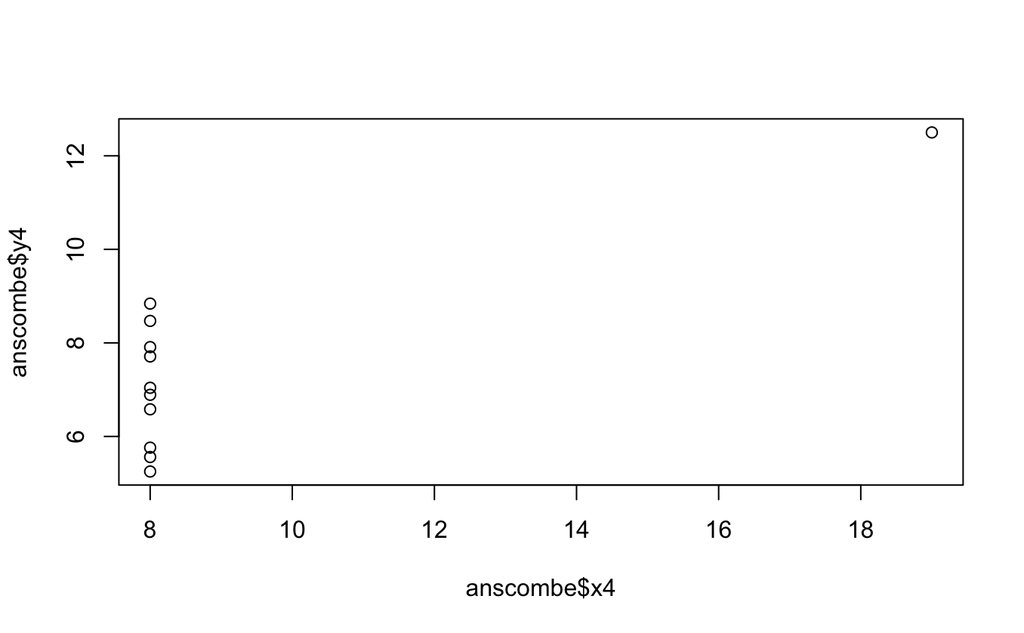

```r
### Plot 4 of x4 vs. y4

plot(anscombe$x4, anscombe$y4)
```

```r
# Challenge 2: Visually estimate the correlation for each of the four scatterplots.



# Challenge 3: Calculate the correlations for each scatterplot to see how close your visual estimates were.
```

What was the main takeaway from the *anscombe* investigation above?

Documentation on anscombe

More on Anscombe’s quartet [here](https://en.wikipedia.org/wiki/Anscombe%27s_quartet)

For another interesting data set to illustrate this same concept, follow this link: [Datasaurus](https://cran.r-project.org/web/packages/datasauRus/vignettes/Datasaurus.html)

## 6. Don’t talk about “correlations” with categorical variables

- Is hair color “correlated” with eye color?
- You cannot calculate correlation with categorical variables:

```r
table(donors$urbanicity, donors$socioEconomicStatus)

#cor(donors$socioEconomicStatus, donors$urbanicity)
```

This material is for enrolled students’ academic use only and protected under U.S. Copyright Laws. This content must not be shared outside the confines of this course, in line with Eastern University’s academic integrity policies. Unauthorized reproduction, distribution, or transmission of this material, including but not limited to posting on third-party platforms like GitHub, is strictly prohibited and may lead to disciplinary action. You may not alter or remove any copyright or other notice from copies of any content taken from BrightSpace or Eastern University’s website. © Copyright Notice 2024, Eastern University - All Rights Reserved